# DS4100 Project - Anime Stats

Business Understanding:

This project aims to analyze the relationships between the popularity, reception, genres, length, and types of different anime.

The particular data set comes from a Kaggle entry (URL: https://www.kaggle.com/CooperUnion/anime-recommendations-database) that seeks to build an anime recommendation system. This entry acquired the data from MyAnimeList.net, a public website for anime to log their anime consumption and provide their input of their impressions of what they’ve seen. This database is particularly unique. Anime is a form of media made by and largely for an Eastern audience (mostly Japanese but also Chinese, Korean, and Vietnamese to a lesser extent) while MyAnimeList.net is a website run and used by a Western audience, primarily consisting of English, Spanish, French, and German speakers. Essentially, this provides data about the impressions of Eastern media by a Western audience which could be drastically different from data investigating Eastern audiences. Repeating this project over such a data set to draw comparisons and analyze possible reasons for differences between the two is a potential followup to this project.

The project should identify how strong a relationship there is between popularity, reception, genres, length, and types of different anime and produce a few models capable of making predictions about a feature given the others.

Data understanding:

We begin by collecting the data through a csv file provided by a Kaggle user. The original data is left untouched while a copy is modified for better analysis. For clarification, “members” refers to the number of people who have watched the anime, indicating its popularity. String splitting was used to determine a vector of genres for each entry rather than an unparsed string listing them. These vectors of genres were used to create a list of all unique genres across entires that would be used later.

```r
dtf_original <- read.csv("anime.csv", stringsAsFactors = FALSE)
dtf <- dtf_original
dtf$episodes <- as.numeric(dtf$episodes)
```

```
NAs introduced by coercion
```

```r
dtf$type <- as.factor(dtf$type)
# Purpose: parses genre string into string vector of genres
# Args: genreString (character) - comma separated genre string from data
# Returns: (character vector) - vector with separate genres
genreVec <- function(genreString) {
  return(strsplit(genreString, ", ")[[1]])
}
# Transforms all genre strings into more usable genre vectors
dtf$genreVec <- sapply(dtf$genre, genreVec)
# List of all of the unique genres
allGenres <- Reduce(union, dtf$genreVec)
allTypes <- levels(factor(dtf$type))
```

A few different approaches were taken to exploring the data. First, the distribution of the two primary continuous variables in question, rating and members, were examined through histograms. The histograms suggested that roughly, rating had a normal distribution and members had a poisson distribution.

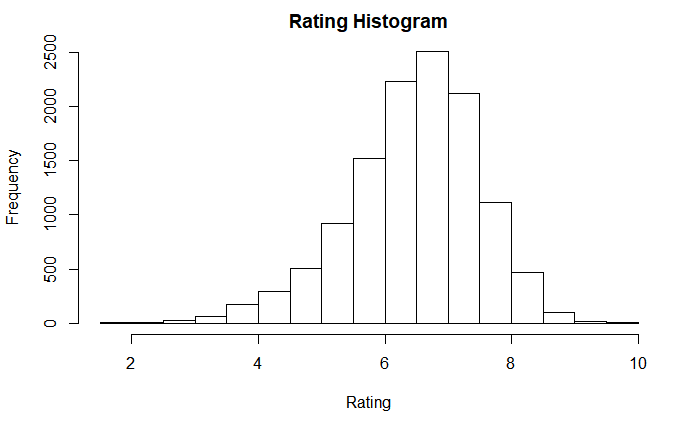

```r
hist(dtf$rating, main="Rating Histogram", xlab="Rating")
```

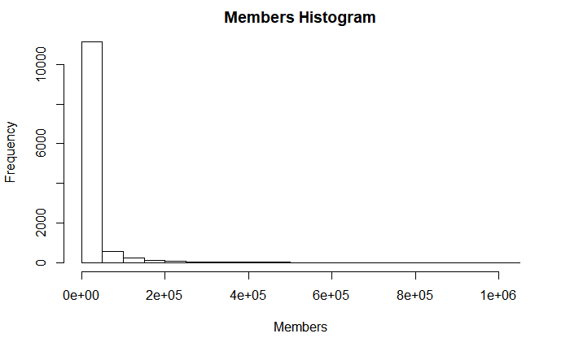

```r
hist(dtf$members, main="Members Histogram", xlab="Members")
```

Outliers hindered manual observation, so they were removed just for the observation phase. They were largely left in for analysis (outliers explained further below).

Exploratory data plots:

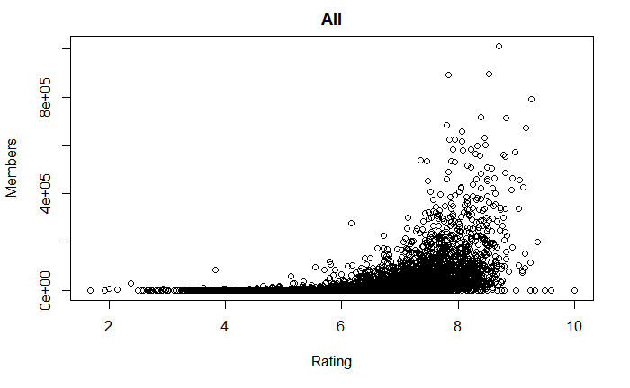

```r
# Purpose: plots the rating vs members for the given dataframe
# Args: df (dataframe) - dataframe to plot, title (character) - title for plot
# Returns: None
plotRM <- function(df, title) {
  plot(df$rating, df$members, main=title, xlab="Rating", ylab="Members")
}
plotRM(dtf, "All")
```

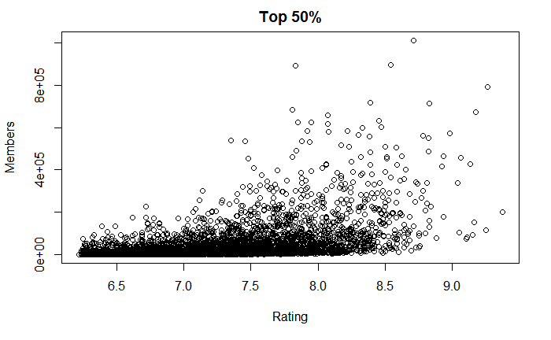

```r
dtf_member_sorted <- dtf[order(-dtf$members),]
topNum <- floor(nrow(dtf) * .5)
dtf_top <- dtf[1:topNum,]
dtf_bot <- dtf[-(1:topNum),]
plotRM(dtf_top, "Top 50%")
```

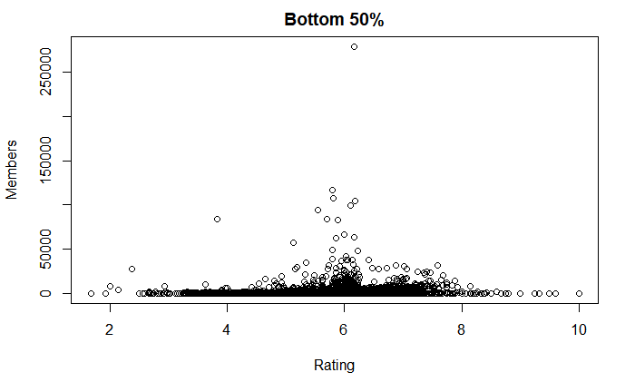

```r
plotRM(dtf_bot, "Bottom 50%")
```

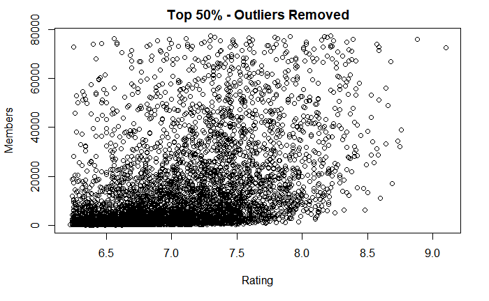

```r
top_out <- boxplot.stats(dtf_top$members)$out
dtf_top_out_rm <- dtf_top[!(is.element(dtf_top$members, top_out)),]
plotRM(dtf_top_out_rm, "Top 50% - Outliers Removed")
```

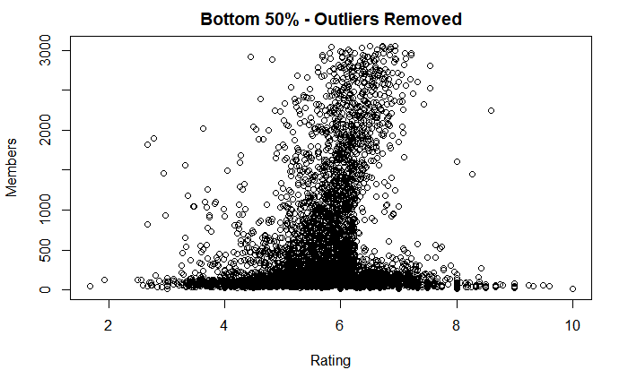

```r
bot_out <- boxplot.stats(dtf_bot$members)$out
dtf_bot_out_rm <- dtf_bot[!(is.element(dtf_bot$members, bot_out)),]
plotRM(dtf_bot_out_rm, "Bottom 50% - Outliers Removed")
```

Outliers for rating and popularity were determined for the entire dataset. Outliers were determined using the built-in boxplot stats which determines anything outside of 1.5 times the interquartile range (75th-25th percentile) as an outlier. Upon examination, it was determined best to keep these in place rather than remove them. The outliers are concentrated rather than individually spread. A large group of low ranking or low popularity anime make up the outliers while the top outliers command the highest ratings or highest popularity, meaning they are a reflection of the most people in the community. Therefore, since removing these before analysis would produce a less accurate representation of the data, a majority of them was kept. However, it was noted that some shows had extremely low popularity with very extreme ratings. Shows with extremely few members were volatile in that very few scores would push its rating drastically upwards or downwards, so they were not very representative of the opinion of the community as a whole. Therefore, entries with outliers in ratings (high or low) and outliers in members on the low side were removed.

```r
ratingOut <- boxplot.stats(dtf$rating)$out
membersOut <- boxplot.stats(dtf$members)$out
length(ratingOut)
```

```
[1] 229
```

```r
head(ratingOut, 30)
```

```
 [1] 9.37 9.26 9.25 9.17 9.16 9.15 9.13 3.91 3.90 3.90 3.88 3.88 3.87 3.86 3.84 3.83 3.83 3.82 3.80 3.78 3.76 3.75 3.74 3.73 3.71 3.70 3.68 3.68 3.65 3.63
```

```r
length(membersOut)
```

```
[1] 1900
```

```r
head(membersOut, 30)
```

```
 [1] 200630 793665 114262 673572 151266  93351 425855  80679  72534  81109 456749 102733 336376 572888 179342 466254 416397  75894 226193 715151 157670 129307 486824 552458 339556
[26] 240297 205959 101351 300030 562962
```

```r
membersAvg <- mean(dtf$members)
dtf <- dtf[!(is.element(dtf$rating, ratingOut) & is.element(dtf$members, membersOut)
             & (dtf$members < membersAvg)),]
```

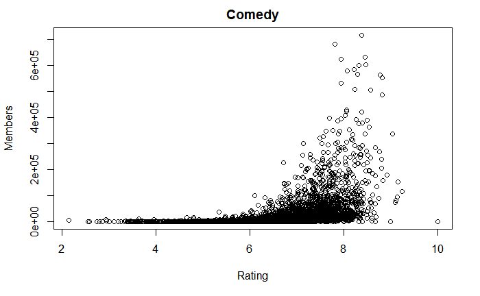

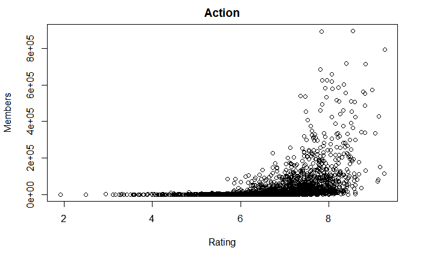

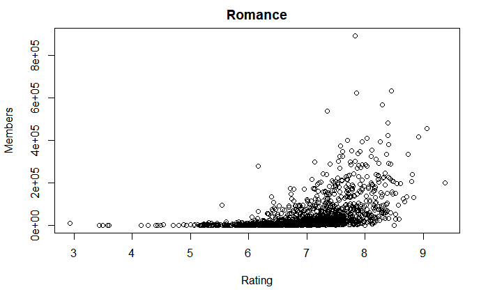

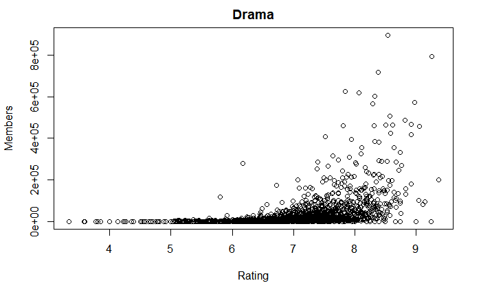

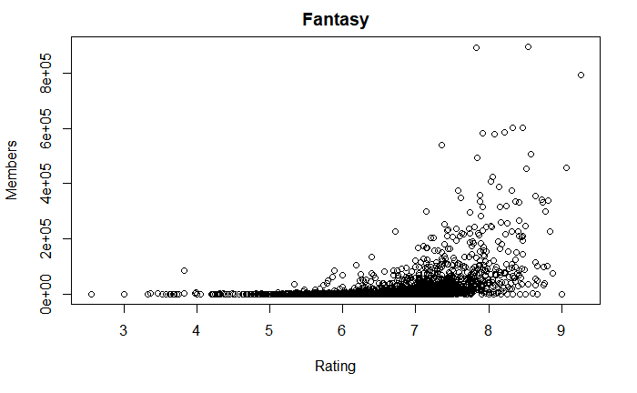

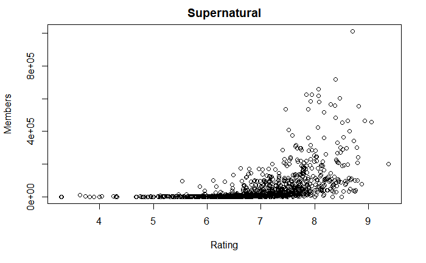

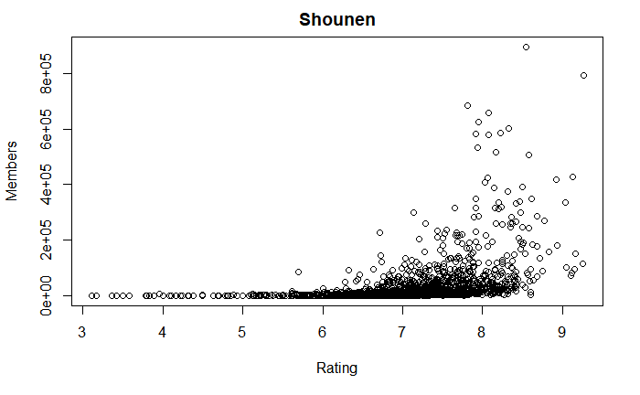

```r
# Purpose: finds the sum members of shows of the given genre
# Args: (character) g - the genre in question
# Returns: (numeric) - the sum members of shows of this genre
howManyMembers <- function(g) {
  return(sum(sapply(c(1:nrow(dtf)), function(row){
    if (grepl(g, dtf[row,]$genre)) {
      return(dtf[row,]$members)
    }
    else {
      return(0)
    }
  })))
}
# This code was used to find which genres were the most popular.
# This is not necessary to repeat now that the information is known,
# but it could be run again if necessary but uncommenting it.
#if (!exists("genrePop")) {
#  genrePop <- data.frame(allGenres, sapply(allGenres, howManyMembers))
#  colnames(genrePop) <- c("Genre", "TotalMembers")
#  genrePop <- genrePop[order(-genrePop$TotalMembers),]
#}
# Purpose: plots rating vs members for shows with the given genre
# Args: (character) g - genre of interest
# Returns: none
plotGenre <- function(g) {
  dtf_sub <- dtf[grep(g, dtf$genre),]
  plotRM(dtf_sub, g)
}
popGenres <- c("Comedy","Action","Romance","Drama","Fantasy", "Supernatural","Shounen")
invisible(sapply(popGenres, plotGenre))
```

Data Preparation:

The data needed to be cleaned in certain ways before analysis, particularly in regards to missing data. Entries missing both their rating were shows that had not yet aired. As these do not reflect what the audience has actually seen, they were simply removed. Of the entries remaining missing their episode count, a large portion of them were under the category of “Hentai.” To ensure more complete data using this information, the applicable entries had their episode counts imputed to the floored average of the entries of that category that did have their episode counts listed. Some of the remaining entries were then filled in manually because they were known exceptions from previous knowledge that would greatly impact the data if filled in using the average. The remaining entries missing their episode counts had them imputed using the average of their respective type. Entries of the type “Music” were also removed entirely. This was done for a few reasons. Entries of this type are animated music videos, something fundamentally different from animated shorts, TV series, movies, or specials. Because this category has such fundamentally standards and audiences, it introduced information that was not relevant to the rest of the data. Thus, it was removed.

```r
allTypes <- allTypes[!allTypes=="Music"]
dtf <- dtf[!(dtf$type == "Music" | is.na(dtf$rating)),]
dtf_H <- dtf[grep("Hentai", dtf$genre),]
h_floored_mean <- floor(mean(dtf_H$episodes, na.rm = TRUE)) # 2
dtf[is.na(dtf$episodes) & grepl("Hentai", dtf$genre),]$episodes <- h_floored_mean
dtf[dtf$name == "Sazae-san",]$episodes <- 7542
dtf <- dtf[!dtf$name == "Sazae-san",]
dtf[dtf$name == "Nintama Rantarou",]$episodes <- 2017
dtf[dtf$name == "Ojarumaru",]$episodes <- 1677
dtf[dtf$name == "Sore Ike! Anpanman",]$episodes <- 1399
dtf[dtf$name == "Chibi Maruko-chan",]$episodes <- 1143
dtf[dtf$name == "Crayon Shin-chan",]$episodes <- 958
dtf[dtf$name == "Doraemon (2005)",]$episodes <- 911
dtf[dtf$name == "Detective Conan",]$episodes <- 897
dtf[dtf$name == "One Piece",]$episodes <- 831
dtf[dtf$name == "Hanakappa",]$episodes <- 485
dtf[dtf$name == "Naruto: Shippuuden",]$episodes <- 500
# Purpose: imputes the episode counts for all entries of that type
# Args: (character) type - type to impute for
# Returns: None
imputeEpisodes <- function(t) {
  typeMean <- mean(dtf[dtf$type == t,]$episodes, na.rm = TRUE)
  if (nrow(dtf[dtf$type == t & is.na(dtf$episodes),]) > 0) {
    dtf[dtf$type == t & is.na(dtf$episodes),]$episodes <<- typeMean
  }
  return(NULL)
}
invisible(sapply(allTypes, imputeEpisodes))
```

The data needed to be normalized before constructing models. The various numeric features were normalized using min-max. These changes were made in a new copy of the dataframe. The categorical features of type and genre needed to be accounted for through feature engineering of dummy codes.

```r
dtf_norm <- dtf
# Purpose: performs min-max normalization on the given column vector/list
# Args: col (vector) - column vector
# Returns: (vector) - column vector after min-max normalization
min_max <- function(col) {
  colMin <- min(col)
  colMax <- max(col)
  denom <- colMax - colMin
  return(sapply(col, function(entry){
    return((entry - colMin)/denom)
  }))
}
dtf_norm$rating <- min_max(dtf_norm$rating)
dtf_norm$episodes <- min_max(dtf_norm$episodes)
dtf_norm$members <- min_max(dtf_norm$members)
# Purpose: adds new column with dummy feature for genre to normalized dataframe
# Args: (character) g - genre to add feature for
# Returns: None
addGenreColumn <- function(g) {
  colVec <- sapply(c(1:nrow(dtf_norm)), function(row) {
    if (is.element(g, dtf_norm[row,]$genreVec[[1]])) {
      return(1)
    }
    else {
      return(0)
    }
  })
  dtf_norm[g] <<- colVec
  return(NULL)
}
# Takes a long time due to generating dozens of columns
invisible(sapply(allGenres, addGenreColumn))
allTypes <- allTypes[allTypes != ""]
# Takes less time than previous step but still a while
invisible(sapply(allTypes, function(t) {
  colVec <- sapply(c(1:nrow(dtf_norm)), function(row) {
    if (dtf_norm[row,]$type == t) {
      return(1)
    }
    else {
      return(0)
    }
  })
  dtf_norm[t] <<- colVec
  return(NULL)
}))
```

Modeling & Evaluation:

Training and validation sets were chosen randomly with 70% used for training and 30% used for validation.

```r
# Training and Validation Sets
set.seed(100) # number doesn't matter - used for reproducible random seed
train_indices <- sample(seq_len(nrow(dtf_norm)), size=floor(0.7*nrow(dtf_norm)))
train_set <- dtf_norm[train_indices,]
test_set <- dtf_norm[-train_indices,]
glmForm <- as.formula(paste("rating ~ episodes + members + ", paste(allTypes, collapse=" + "), " + ", paste(sprintf("get('%s')", allGenres), collapse=" + ")))
iden <- glm(glmForm, data=train_set)
summary(iden)
```

```
Call:
glm(formula = glmForm, data = train_set)

Deviance Residuals:
     Min        1Q    Median        3Q       Max
-0.56150  -0.05456   0.00757   0.06444   0.46901

Coefficients: (1 not defined because of singularities)
                       Estimate Std. Error t value Pr(>|t|)
(Intercept)           0.5303111  0.0036430 145.569  < 2e-16 ***
episodes              0.1095427  0.0422283   2.594  0.00950 **
members               0.5733214  0.0231812  24.732  < 2e-16 ***
Movie                -0.0274650  0.0034729  -7.908 2.96e-15 ***
ONA                  -0.0918591  0.0052851 -17.381  < 2e-16 ***
OVA                  -0.0181464  0.0034295  -5.291 1.25e-07 ***
Special              -0.0069777  0.0036916  -1.890  0.05878 .
TV                           NA         NA      NA       NA
get("Drama")          0.0509829  0.0032145  15.860  < 2e-16 ***
get("Romance")        0.0188874  0.0038349   4.925 8.60e-07 ***
get("School")         0.0320321  0.0040531   7.903 3.08e-15 ***
get("Supernatural")   0.0187576  0.0043901   4.273 1.95e-05 ***
get("Action")         0.0124715  0.0031013   4.021 5.84e-05 ***
get("Adventure")      0.0184326  0.0030826   5.980 2.33e-09 ***
get("Fantasy")        0.0233760  0.0031297   7.469 8.93e-14 ***
get("Magic")          0.0142486  0.0048307   2.950  0.00319 **
get("Military")       0.0430205  0.0064194   6.702 2.20e-11 ***
get("Shounen")        0.0464657  0.0035151  13.219  < 2e-16 ***
get("Comedy")         0.0157554  0.0026221   6.009 1.95e-09 ***
get("Historical")     0.0340756  0.0047418   7.186 7.25e-13 ***
get("Parody")         0.0123892  0.0061173   2.025  0.04287 *
get("Samurai")        0.0008713  0.0106733   0.082  0.93494
get("Sci-Fi")         0.0151764  0.0035492   4.276 1.92e-05 ***
get("Thriller")       0.0397062  0.0134576   2.950  0.00318 **
get("Sports")         0.0299560  0.0056436   5.308 1.14e-07 ***
get("Super Power")    0.0062877  0.0061318   1.025  0.30519
get("Space")          0.0076270  0.0068417   1.115  0.26498
get("Slice of Life")  0.0229646  0.0039600   5.799 6.92e-09 ***
get("Mecha")          0.0001729  0.0047487   0.036  0.97096
get("Music")          0.0088752  0.0066820   1.328  0.18414
get("Mystery")        0.0405370  0.0061204   6.623 3.74e-11 ***
```

[output cut: 15 more lines]

```
get("Kids")          -0.0117441  0.0036366  -3.229  0.00125 **
get("Shoujo Ai")      0.0121780  0.0158447   0.769  0.44216
get("Hentai")         0.0214173  0.0048394   4.426 9.74e-06 ***
get("Yaoi")          -0.0180144  0.0185577  -0.971  0.33172
get("Yuri")          -0.0160906  0.0188897  -0.852  0.39434
---
Signif. codes:  0 *** 0.001 ** 0.01 * 0.05 . 0.1   1

(Dispersion parameter for gaussian family taken to be 0.009730557)

    Null deviance: 120.08  on 8101  degrees of freedom
Residual deviance:  78.35  on 8052  degrees of freedom
AIC: -14488

Number of Fisher Scoring iterations: 2
```

The results above indicate that with .01 as the baseline for statistical significance, a number of categories are statistically insignificant. These are removed in the next iteration to better fit the model. There is also a singularity of TV. The colinearity matrix is observed below to identify this.

```r
alias(iden)
```

```
Model :
rating ~ episodes + members + Movie + ONA + OVA + Special + TV +
    get("Drama") + get("Romance") + get("School") + get("Supernatural") +
    get("Action") + get("Adventure") + get("Fantasy") + get("Magic") +
    get("Military") + get("Shounen") + get("Comedy") + get("Historical") +
    get("Parody") + get("Samurai") + get("Sci-Fi") + get("Thriller") +
    get("Sports") + get("Super Power") + get("Space") + get("Slice of Life") +
    get("Mecha") + get("Music") + get("Mystery") + get("Seinen") +
    get("Martial Arts") + get("Vampire") + get("Shoujo") + get("Horror") +
    get("Police") + get("Psychological") + get("Demons") + get("Ecchi") +
    get("Josei") + get("Shounen Ai") + get("Game") + get("Dementia") +
    get("Harem") + get("Cars") + get("Kids") + get("Shoujo Ai") +
    get("Hentai") + get("Yaoi") + get("Yuri")

Complete :
   (Intercept) episodes members Movie ONA OVA Special get("Drama") get("Romance") get("School") get("Supernatural") get("Action") get("Adventure") get("Fantasy") get("Magic")
TV  1           0        0      -1    -1  -1  -1       0            0              0             0                   0             0                0              0
   get("Military") get("Shounen") get("Comedy") get("Historical") get("Parody") get("Samurai") get("Sci-Fi") get("Thriller") get("Sports") get("Super Power") get("Space")
TV  0               0              0             0                 0             0              0             0               0             0                  0
   get("Slice of Life") get("Mecha") get("Music") get("Mystery") get("Seinen") get("Martial Arts") get("Vampire") get("Shoujo") get("Horror") get("Police") get("Psychological")
TV  0                    0            0            0              0             0                   0              0             0             0             0
   get("Demons") get("Ecchi") get("Josei") get("Shounen Ai") get("Game") get("Dementia") get("Harem") get("Cars") get("Kids") get("Shoujo Ai") get("Hentai") get("Yaoi") get("Yuri")
TV  0             0            0            0                 0           0               0            0           0           0                0             0           0
```

Ultimately, one of the dummy features for type is unnecessary because types are mutually exclusive, and thus one type can be expressed by showing 0 on all other type dummy features. Since TV is of particular interest, the least statistically significant type, “Special”, is removed instead.

```r
unwantedGenres <- c("Parody", "Samurai", "Super Power", "Space", "Mecha", "Music", "Martial Arts", "Vampire", "Psychological", "Demons", "Ecchi", "Shounen Ai", "Harem", "Game", "Cars", "Shoujo Ai", "Yaoi", "Yuri")
glmForm2 <- as.formula(paste("rating ~ episodes + members + Movie + ONA + OVA + TV + ", paste(sprintf("get('%s')", setdiff(allGenres, unwantedGenres)), collapse=" + ")))
iden2 <- glm(glmForm2, data=train_set)
summary(iden2)
```

```
Call:
glm(formula = glmForm2, data = train_set)

Deviance Residuals:
     Min        1Q    Median        3Q       Max
-0.56401  -0.05467   0.00731   0.06417   0.47985

Coefficients:
                      Estimate Std. Error t value Pr(>|t|)
(Intercept)           0.525307   0.003705 141.772  < 2e-16 ***
episodes              0.108403   0.042238   2.567 0.010291 *
members               0.578444   0.022917  25.241  < 2e-16 ***
Movie                -0.020238   0.003913  -5.172 2.37e-07 ***
ONA                  -0.083924   0.005504 -15.247  < 2e-16 ***
OVA                  -0.011505   0.003849  -2.989 0.002809 **
TV                    0.007523   0.003680   2.044 0.040975 *
get("Drama")          0.051888   0.003186  16.285  < 2e-16 ***
get("Romance")        0.017795   0.003698   4.812 1.52e-06 ***
get("School")         0.030971   0.003995   7.752 1.01e-14 ***
get("Supernatural")   0.016820   0.004275   3.935 8.40e-05 ***
get("Action")         0.013339   0.002954   4.516 6.41e-06 ***
get("Adventure")      0.018120   0.003067   5.908 3.60e-09 ***
get("Fantasy")        0.022630   0.003105   7.289 3.43e-13 ***
get("Magic")          0.012745   0.004812   2.649 0.008096 **
get("Military")       0.042687   0.006200   6.885 6.20e-12 ***
get("Shounen")        0.046629   0.003487  13.371  < 2e-16 ***
get("Comedy")         0.015076   0.002548   5.918 3.39e-09 ***
get("Historical")     0.033715   0.004547   7.414 1.35e-13 ***
get("Sci-Fi")         0.015838   0.003248   4.876 1.11e-06 ***
get("Thriller")       0.044215   0.013345   3.313 0.000926 ***
get("Sports")         0.028329   0.005555   5.100 3.48e-07 ***
get("Slice of Life")  0.022842   0.003918   5.830 5.75e-09 ***
get("Mystery")        0.041650   0.006073   6.858 7.50e-12 ***
get("Seinen")         0.030680   0.005594   5.485 4.27e-08 ***
get("Shoujo")         0.028744   0.005424   5.300 1.19e-07 ***
get("Horror")        -0.019412   0.006698  -2.898 0.003762 **
get("Police")         0.053739   0.009317   5.768 8.32e-09 ***
get("Josei")          0.075703   0.016686   4.537 5.79e-06 ***
get("Dementia")      -0.119314   0.008338 -14.310  < 2e-16 ***
get("Kids")          -0.012913   0.003606  -3.581 0.000344 ***
get("Hentai")         0.019511   0.004732   4.123 3.78e-05 ***
---
Signif. codes:  0 *** 0.001 ** 0.01 * 0.05 . 0.1   1

(Dispersion parameter for gaussian family taken to be 0.00975141)

    Null deviance: 120.077  on 8101  degrees of freedom
Residual deviance:  78.694  on 8070  degrees of freedom
AIC: -14489

Number of Fisher Scoring iterations: 2
```

Predictions were made to evaluate the model’s accuracy. Accuracy was measured in three ways: correlation, min max accuracy, and mean absolute percentage error (MAPE).

```r
glm_predictions <- predict(iden2, test_set, type="response")
reg_cor <- cor(test_set$rating, glm_predictions)
# Purpose: calculates the min max accuracy of the test set and predictions
# Args: (dataframe) ts - test set, (vector) pred - predictions,
#       (character) cName - column to predict
# Returns: (numeric) - min max accuracy of predictions
acc_min_max <- function(ts, pred, cName) {
  return(mean(sapply(1:nrow(ts), function(row) {
    actual <- ts[row,cName]
    predicted <- pred[row]
    return(min(actual, predicted)/max(actual, predicted))
  })))
}
reg_min_max <- acc_min_max(test_set, glm_predictions, "rating")
# Purpose: calculates the Mean Absolute Percentage Error of the test set and predictions
# Args: (dataframe) ts - test set, (vector) pred - predictions,
#       (character) cName - column to predict
# Returns: (numeric) - Mean Absolute Percentage Error (MAPE)
acc_mape <- function(ts, pred, cName) {
  return(mean(sapply(1:nrow(ts), function(row) {
    actual <- ts[row,cName]
    predicted <- pred[row]
    return(abs(predicted - actual)/actual)
  })))
}
reg_mape <- acc_mape(test_set, glm_predictions, "rating")
paste("Correlation: ", reg_cor)
```

```
[1] "Correlation:  0.601730565568474"
```

```r
paste("Min Max Accuracy: ", reg_min_max)
```

```
[1] "Min Max Accuracy:  0.880168214376317"
```

```r
paste("Mean Absolute Percentage Error (MAPE): ", reg_mape)
```

```
[1] "Mean Absolute Percentage Error (MAPE):  0.155087902855952"
```

These results illustrated that the model had good predictive ability on average but weaker correlation with the individual results. The relatively high min max accuracy and relatively low MAPE suggest that the model is a good fit for making predictions about rating. The coefficients suggest that despite suspicions people may have about popular shows, the number of members is a fairly good predictor of the rating overall. The episode count seems to have some influence on this as well, and this could be explained with the idea that shows that are well received are more likely to get more and more episodes made while shows that are’t well received are likely to be cut fairly short. As for genre as a predictor, more niche genres appear to paint a clearer image of how the rating will turn out. The Josei genre, a genre intended for older female audiences, has relatively smaller audiences, but shows of the genre tend to be well received. The Dementia genre on the other hand seems to be very poorly received even though it has a relatively small audience like the Josei genre. Overall, the more popular a genre, the less influence the genre itself seems to have on the rating, likely due to oversaturation of good and bad shows.

To test whether the model tended to overshoot or undershoot, a simple count of how many of each it did was conducted below.

```r
undershoot <- sum(sapply(1:nrow(test_set), function(row){
  if (glm_predictions[row] < test_set[row,]$rating) {
    return(1)
  }
  else {
    return(0)
  }
}))
overshoot <- sum(sapply(1:nrow(test_set), function(row){
  if (glm_predictions[row] > test_set[row,]$rating) {
    return(1)
  }
  else {
    return(0)
  }
}))
paste("Undershoot %: ", undershoot/nrow(test_set))
```

```
[1] "Undershoot %:  0.534696228044918"
```

```r
paste("Overshoot %: ", overshoot/nrow(test_set))
```

```
[1] "Overshoot %:  0.465303771955082"
```

```r
paste("Exact %: ", (nrow(test_set) - (undershoot + overshoot))/nrow(test_set))
```

```
[1] "Exact %:  0"
```

Another model would provide a point of comparison for accuracy of guessing rating based on the other factors. Below, the kNN model for regression is used to predict rating. The models below are created with various values of k centered around the suggested square-root of the number of features.

```r
library("DMwR")
dtf_knn <- dtf_norm[,-(c(1:4, 8))]
train_set_knn <- dtf_knn[train_indices,]
test_set_knn <- dtf_knn[-train_indices,]
# Purpose: performs kNN using given k and displays three measures of accuracy
# Args: (numeric) kVal - k value to use
# Returns: (numeric vector) - correlation, min-max accuracy, and MAPE
# Prints: Correlation, Min-Max Accuracy, and MAPE
evalK <- function(kVal) {
  knnK <- kNN(rating ~ ., train_set_knn, test_set_knn,k=kVal)
  knnK_num <- as.numeric(levels(knnK))[knnK]
  knnK_cor <- cor(test_set_knn$rating, knnK_num)
  knnK_min_max <- acc_min_max(test_set_knn, knnK_num, "rating")
  knnK_mape <- acc_mape(test_set_knn, knnK_num, "rating")
  print(paste("For k value of: ", kVal))
  print(paste("Correlation: ", knnK_cor))
  print(paste("Min Max Accuracy: ", knnK_min_max))
  print(paste("Mean Absolute Percentage Error (MAPE): ", knnK_mape))
  # return(c(knnK_cor, knnK_min_max, knnK_mape))
}
sqrtK <- floor(sqrt(ncol(train_set_knn)))
evalK(3)
```

```
[1] "For k value of:  3"
[1] "Correlation:  0.502420177708996"
[1] "Min Max Accuracy:  0.856413171626291"
[1] "Mean Absolute Percentage Error (MAPE):  0.178977843909109"
```

```r
evalK(5)
```

```
[1] "For k value of:  5"
[1] "Correlation:  0.478860797025965"
[1] "Min Max Accuracy:  0.853457613655283"
[1] "Mean Absolute Percentage Error (MAPE):  0.179689332387371"
```

```r
evalK(sqrtK)
```

```
[1] "For k value of:  7"
[1] "Correlation:  0.453367589181467"
[1] "Min Max Accuracy:  0.849708408277861"
[1] "Mean Absolute Percentage Error (MAPE):  0.185623731277217"
```

```r
evalK(9)
```

```
[1] "For k value of:  9"
[1] "Correlation:  0.446876920939352"
[1] "Min Max Accuracy:  0.847039834102047"
[1] "Mean Absolute Percentage Error (MAPE):  0.187487490276971"
```

```r
evalK(11)
```

```
[1] "For k value of:  11"
[1] "Correlation:  0.420517985186714"
[1] "Min Max Accuracy:  0.847765452406773"
[1] "Mean Absolute Percentage Error (MAPE):  0.190916121575414"
```

The multiple regression model seems to work better than the kNN model overall. Even at its oddly best k value of 3, the kNN model produced higher rates of error than the multiple regression model on all measures of accuracy.

The relationship between the genre and other features is worth analyzing, particularly when it comes to identifying “Hentai” since this could be used to censor mature content in the appropriate settings. A logistic regression model is used for this purpose.

```r
logistic_form <- as.formula(paste("get('Hentai') ~ rating + episodes + members + ", paste(sprintf("get('%s')", allGenres[allGenres!="Hentai"]), collapse=" + ")))
logit <- glm(logistic_form, data = train_set, family = "binomial")
```

```
glm.fit: fitted probabilities numerically 0 or 1 occurred
```

```r
summary(logit)
```

```
Call:
glm(formula = logistic_form, family = "binomial", data = train_set)

Deviance Residuals:
    Min       1Q   Median       3Q      Max
-2.6068  -0.0712  -0.0001   0.0000   4.7910

Coefficients:
                       Estimate Std. Error z value Pr(>|z|)
(Intercept)             0.12749    0.35351   0.361 0.718368
rating                  2.94419    0.66687   4.415 1.01e-05 ***
episodes             -204.60794   38.89588  -5.260 1.44e-07 ***
members               -48.49183   12.64522  -3.835 0.000126 ***
get("Drama")           -3.29988    0.27192 -12.136  < 2e-16 ***
get("Romance")         -0.23387    0.28352  -0.825 0.409445
get("School")          -0.48657    0.29519  -1.648 0.099285 .
get("Supernatural")    -0.08254    0.27394  -0.301 0.763168
get("Action")          -1.82119    0.24578  -7.410 1.26e-13 ***
get("Adventure")       -3.60455    0.38388  -9.390  < 2e-16 ***
get("Fantasy")         -2.22072    0.20377 -10.898  < 2e-16 ***
get("Magic")           -1.31928    0.36707  -3.594 0.000326 ***
get("Military")        -2.44356    0.79765  -3.063 0.002188 **
get("Shounen")        -17.98553  572.55493  -0.031 0.974940
get("Comedy")          -3.83121    0.20530 -18.661  < 2e-16 ***
get("Historical")      -3.83307    0.42422  -9.036  < 2e-16 ***
get("Parody")          -1.06460    0.49374  -2.156 0.031068 *
get("Samurai")        -18.03060 2033.73524  -0.009 0.992926
get("Sci-Fi")          -1.97017    0.27416  -7.186 6.66e-13 ***
get("Thriller")       -18.49010 2495.16878  -0.007 0.994087
get("Sports")          -4.03624    0.73677  -5.478 4.29e-08 ***
get("Super Power")     -0.82433    0.59263  -1.391 0.164234
get("Space")           -0.72124    0.62476  -1.154 0.248322
get("Slice of Life")   -5.59339    1.01155  -5.530 3.21e-08 ***
get("Mecha")           -2.64452    0.49383  -5.355 8.55e-08 ***
get("Music")           -5.11127    1.01663  -5.028 4.97e-07 ***
get("Mystery")         -2.29607    0.53571  -4.286 1.82e-05 ***
get("Seinen")         -18.74814 1076.85403  -0.017 0.986109
get("Martial Arts")    -0.56780    0.61647  -0.921 0.357018
get("Vampire")        -18.28879 2403.04301  -0.008 0.993928
get("Shoujo")         -19.80817 1011.71445  -0.020 0.984379
```

[output cut: 10 more lines]

```
get("Cars")           -19.08983 2839.97374  -0.007 0.994637
get("Kids")           -20.45436  689.10670  -0.030 0.976320
get("Shoujo Ai")      -39.84300 1818.18440  -0.022 0.982517
get("Yaoi")             1.77662    0.66309   2.679 0.007377 **
get("Yuri")            30.38058 1579.52491   0.019 0.984654
---
Signif. codes:  0 *** 0.001 ** 0.01 * 0.05 . 0.1   1

(Dispersion parameter for binomial family taken to be 1)

    Null deviance: 5310.6  on 8101  degrees of freedom
Residual deviance: 1670.2  on 8056  degrees of freedom
AIC: 1762.2

Number of Fisher Scoring iterations: 20
```

As before, the statistically insignificant ones are removed with the same upper limit of .01 for p-value.

```r
unwantedGenres2 <- c("Hentai", "Romance", "School", "Supernatural", "Shounen", "Parody", "Samurai", "Thriller", "Super Power", "Space", "Seinen", "Martial Arts", "Vampire", "Shoujo", "Police", "Ecchi", "Josei", "Shounen Ai", "Game", "Cars", "Kids", "Shoujo Ai", "Yuri")
logistic_form2 <- as.formula(paste("get('Hentai') ~ rating + episodes + members + ", paste(sprintf("get('%s')", setdiff(allGenres, unwantedGenres2)), collapse=" + ")))
logit2 <- glm(logistic_form2, data = train_set, family = "binomial")
```

```
glm.fit: fitted probabilities numerically 0 or 1 occurred
```

```r
summary(logit2)
```

```
Call:
glm(formula = logistic_form2, family = "binomial", data = train_set)

Deviance Residuals:
    Min       1Q   Median       3Q      Max
-2.4682  -0.2040  -0.0413  -0.0044   5.2992

Coefficients:
                      Estimate Std. Error z value Pr(>|z|)
(Intercept)            -0.9850     0.2811  -3.504 0.000458 ***
rating                  3.3654     0.5361   6.278 3.43e-10 ***
episodes             -236.0709    30.2096  -7.814 5.52e-15 ***
members               -55.1610     9.8701  -5.589 2.29e-08 ***
get("Drama")           -3.2988     0.2485 -13.273  < 2e-16 ***
get("Action")          -2.0072     0.2115  -9.489  < 2e-16 ***
get("Adventure")       -3.5211     0.3710  -9.492  < 2e-16 ***
get("Fantasy")         -2.2245     0.1758 -12.651  < 2e-16 ***
get("Magic")           -1.3637     0.3260  -4.183 2.88e-05 ***
get("Military")        -2.0322     0.7701  -2.639 0.008317 **
get("Comedy")          -3.3968     0.1798 -18.887  < 2e-16 ***
get("Historical")      -3.5106     0.4083  -8.599  < 2e-16 ***
get("Sci-Fi")          -1.6296     0.2398  -6.795 1.09e-11 ***
get("Sports")          -4.1589     0.7204  -5.773 7.80e-09 ***
get("Slice of Life")   -5.0642     1.0073  -5.027 4.98e-07 ***
get("Mecha")           -2.0823     0.4810  -4.329 1.50e-05 ***
get("Music")           -4.6319     1.0109  -4.582 4.60e-06 ***
get("Mystery")         -2.3647     0.4892  -4.834 1.34e-06 ***
get("Horror")          -0.4768     0.2936  -1.624 0.104311
get("Psychological")   -2.0108     0.5598  -3.592 0.000328 ***
get("Demons")           1.6725     0.2811   5.949 2.70e-09 ***
get("Dementia")        -4.8261     1.0100  -4.778 1.77e-06 ***
get("Harem")            0.6021     0.3808   1.581 0.113875
get("Yaoi")             2.4766     0.6003   4.126 3.70e-05 ***
---
Signif. codes:  0 *** 0.001 ** 0.01 * 0.05 . 0.1   1

(Dispersion parameter for binomial family taken to be 1)

    Null deviance: 5310.6  on 8101  degrees of freedom
Residual deviance: 2467.1  on 8078  degrees of freedom
AIC: 2515.1

Number of Fisher Scoring iterations: 10
```

Predictions are made using this logistic regression model and then evaluated with simple accuracy: correct/total.

```r
H_pred <- sapply(predict(logit2, test_set, type="response"), function(prob){
  if (prob > 0.5) {
    return(1)
  }
  else {
    return(0)
  }
})
H_accuracy <- sum(sapply(1:nrow(test_set), function(row) {
  return(H_pred[row] == test_set[row,]$Hentai)
}))/nrow(test_set)
paste("The accuracy of this model in prediction is: ", H_accuracy)
```

```
[1] "The accuracy of this model in prediction is:  0.954218255110855"
```

The model demonstrates strikingly high accuracy, indicating a strong relationship between age-restricted material (Hentai) and the other entries. Note that this is biased because part of the missing data for episode counts for Hentai were previously imputed with a single value, making the relationship between episode count and Hentai stronger artificially.

Deployment:

The project has produced a model that could guess the rating of an anime based on its other factors with relatively high accuracy. The multiple regression model has proven more accurate than kNN at least and highlights some interesting relationships.

As expected, popularity and rating share a close relationship. This could result from highly rated shows becoming popular due to its positive reception. As for genre, more popular genres like shounen and comedy reflect less about the rating while more niche ones like josei and dementia were found to influence it more.

The project has also produced a logistic regression model that could accurately guess an anime as a Hentai. This could be deployed to place age restrictions where necessary. The model suggests the number of viewers and the number of episodes both share a negative relationship with the probability of an anime falling in that category, likely because people are less willing to publicize their viewership data of such a thing.

This project could be repeated with data from a Japanese/Asian audience to denote any strong differences in the viewership patterns of Eastern and Western audiences. This may yield insight into how different cultures impact the different viewing experiences of the same entertainment.